# Project: Investigating Vaccinations in Regards to Infant Mortality

- Introduction
- Data Wrangling
- Exploratory Data Analysis
- Conclusions

## Introduction

**Opening Notes**: This analysis will be an attempt to establish a correlation between vaccination and infant mortality. If one does exist an investigation will be made to see if that pattern extends to overall life expectancy. For this analysis the countries chosen are specifically ones with either a low vaccination and/or high infant mortality starting number. The reasoning for this is to better illustrate an existing relationship between the two variables that might be harder to identify in countries with more established healthcare or vaccination practices (since infant mortality is expected to drop over time, and life expectancy to rise, regardless).

> The main questions looking to be answered are:
> 1. Is there a correlation between different vaccinations and infant mortality?
> 2. If so, does that extend to life expectancy?

> Any inconsistancies in expected outcomes will be researched in order to find a reasonable explanation.

```python
import pandas as pd
import numpy as np
import matplotlib as plt
import seaborn as sns
%matplotlib inline

# Remember to include a 'magic word' so that your visualizations are plotted
#   inline with the notebook. See this page for more:
#   http://ipython.readthedocs.io/en/stable/interactive/magics.html
```

## Data Wrangling

### General Properties

```python
# Load your data and print out a few lines. Perform operations to inspect data
#   types and look for instances of missing or possibly errant data.
mcvdf = pd.read_csv('csv\\mcv_immunized_percent_of_one_year_olds.csv')
dtpdf = pd.read_csv('csv\\dtp3_immunized_percent_of_one_year_olds.csv')
hepbdf = pd.read_csv('csv\\hepb3_immunized_percent_of_one_year_olds.csv')
imdf = pd.read_csv('csv\\child_mortality_0_5_year_olds_dying_per_1000_born.csv')
ledf = pd.read_csv('csv\\life_expectancy_years.csv')
```

```python
mcvdf.head(),dtpdf.head(),hepbdf.head(),imdf.head(),ledf.head()
```

```
(       country  1980  1981  1982  1983  1984  1985  1986  1987  1988  ...   \
 0  Afghanistan  11.0   NaN   8.0   9.0  14.0  14.0  14.0  31.0  34.0  ...
 1      Albania  90.0  90.0  93.0  96.0  96.0  96.0  96.0  96.0  96.0  ...
 2      Algeria   NaN   NaN   NaN   NaN   NaN  68.0  67.0  73.0  81.0  ...
 3      Andorra   NaN   NaN   NaN   NaN   NaN   NaN   NaN   NaN   NaN  ...
 4       Angola   NaN   NaN   NaN  26.0  35.0  44.0  44.0  55.0  56.0  ...

    2002  2003  2004  2005  2006  2007  2008  2009  2010  2011
 0  35.0  39.0  48.0  50.0  53.0  55.0  59.0  60.0  62.0    62
 1  96.0  93.0  96.0  97.0  95.0  97.0  98.0  97.0  99.0    99
 2  81.0  84.0  81.0  83.0  91.0  92.0  88.0  92.0  95.0    95
 3  98.0  96.0  98.0  94.0  91.0  94.0  98.0  98.0  99.0    99
 4  74.0  62.0  64.0  45.0  48.0  88.0  79.0  77.0  93.0    88

 [5 rows x 33 columns],
```

[output cut: 60 more lines]

```python
hepbdf.info()
```

```
<class 'pandas.core.frame.DataFrame'>
RangeIndex: 178 entries, 0 to 177
Data columns (total 24 columns):
country    178 non-null object
1989       3 non-null float64
1990       10 non-null float64
1991       21 non-null float64
1992       30 non-null float64
1993       38 non-null float64
1994       44 non-null float64
1995       54 non-null float64
1996       59 non-null float64
1997       65 non-null float64
1998       70 non-null float64
1999       79 non-null float64
2000       93 non-null float64
2001       103 non-null float64
2002       120 non-null float64
2003       139 non-null float64
2004       146 non-null float64
2005       155 non-null float64
2006       160 non-null float64
2007       169 non-null float64
2008       173 non-null float64
2009       176 non-null float64
2010       178 non-null int64
2011       178 non-null int64
dtypes: float64(21), int64(2), object(1)
memory usage: 33.5+ KB
```

### First Observations:

> **1.** All of the dataframes are in a clear, if difficult to utilize, format. The tables needed to be transposed so that all the years would be in one column, and so the data could be selected by country.

> **2.** Fortunately however they are all formatted in this same way, which means their transposing and cleaning can be automated.

> **3.** Comparing the data will be easiest by breaking these dataframes up into smaller, more concise and manageable, dataframes for each country that will be analyzed.

> **4.** It seems like the HepB3 Vaccine data is just riddled with null values (only reaching ~50% non-null by 2000) meaning the data may need to be compared differently, or abandoned.

### Data Cleaning

```python
#Created a function that takes in the list of dataframes that need to be prepped,
#first the table is transposed, the index is then reset and the columns are remade
#to be the country name, and since 'country' as a column header is now over years
#it gets renamed to 'year'. The index is then reset and the old index column is dropped

tset= [mcvdf,dtpdf,hepbdf,imdf,ledf]

def clean_dataframe(tbl):
    tbl = tbl.T
    tbl = tbl.reset_index()
    tbl.columns = tbl.iloc[0]
    tbl = tbl.iloc[1:,:]
    tbl.rename(columns={'country':'year'}, inplace= True)
    tbl = tbl.reset_index()
    tbl = tbl.drop(columns=['index'])
    return tbl

mcvdf2,dtpdf2,hepbdf2,imdf2,ledf2 = [clean_dataframe(x) for x in tset]
```

As stated above the first thing that needed doing was to transpose the dataframes so that each country's data is in one column. Since doing the above process five separate times would be cluttered and redundant the decision was made to create a function that takes in a list of these dataframes and cleans them, automating the process.

```python
#Quickly throwing away any data from before 1980

imdf2 = imdf2.iloc[180:,:]
imdf2 = imdf2.reset_index(drop=True)
letrim = ledf2.iloc[180:217,:]
ledf2 = letrim.reset_index(drop=True)
```

Since most of the vaccine data roughly begins around the 1980's all the life expectancy and infant mortality data from before that time needed to be dropped.

```python
imdf2.iloc[:,0:].max().sort_values(ascending=False)
```

```
0
year                 2018.0
Niger                 338.0
Mali                  324.0
South Sudan           298.0
Sierra Leone          288.0
Rwanda                284.0
Guinea                283.0
Liberia               260.0
Mozambique            259.0
Guinea-Bissau         253.0
Malawi                252.0
Afghanistan           245.0
Ethiopia              240.0
Burkina Faso          238.0
Chad                  237.0
Gambia                237.0
Angola                236.0
Timor-Leste           236.0
Equatorial Guinea     236.0
Burundi               221.0
Uganda                216.0
Nigeria               215.0
Benin                 215.0
Congo, Dem. Rep.      210.0
Nepal                 209.0
Haiti                 208.0
Yemen                 207.0
Senegal               205.0
Somalia               203.0
Lao                   202.0
                      ...
Greece                 19.6
Brunei                 18.9
Slovenia               18.3
Israel                 18.1
Malta                  17.0
Austria                16.2
Italy                  16.1
New Zealand            15.6
```

[output cut: 8 more lines]

```
Luxembourg             13.5
Australia              13.0
Andorra                12.9
Canada                 12.5
France                 12.4
Netherlands            10.9
Switzerland            10.4
Norway                 10.2
Denmark                10.0
Japan                   9.9
Iceland                 9.7
Monaco                  9.7
Finland                 8.7
Sweden                  8.4
Length: 194, dtype: float64
```

```python
imdf_test = imdf[['country','1980']]

imdf_test.set_index('country',inplace=True)

imdf_test = imdf_test.loc[['Niger','Mali','Guinea','United States','Sierra Leone','Rwanda','India']]

imdf_test = imdf2[['Niger','Mali','Guinea','United States','Sierra Leone','Rwanda','India']]
```

```
Text(0.5,1,'Infant Mortality Per 1k Births Data Samples')
```

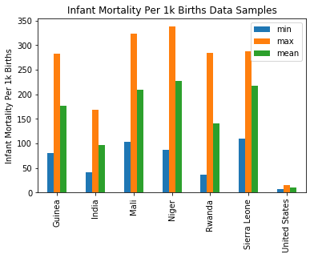

```python
stat_df = pd.DataFrame()

stat_df = stat_df.append(pd.Series(imdf_test.min(), name='min'))
stat_df = stat_df.append(pd.Series(imdf_test.max(), name='max'))
stat_df = stat_df.append(pd.Series(imdf_test.mean(), name='mean'))

stat_df.T.plot.bar()
plt.pyplot.ylabel('Infant Mortality Per 1k Births')
plt.pyplot.title('Infant Mortality Per 1k Births Data Samples')
```

> As has been stated before, and will be again: In deciding which countries to analyze attention was given to which countries had a low vaccination percentage, and especially a high infant mortality rate. Samples from those countries (as well as India for its low vaccinations, and the United States as a possibly interesting set to compare against) were set aside and the min, max, and mean of the data was then calculated and set to a graph for easy visualization.

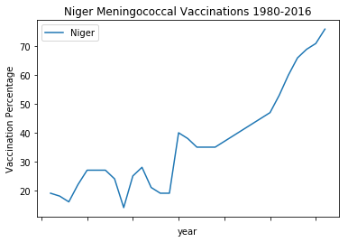

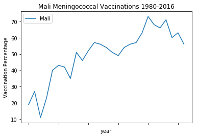

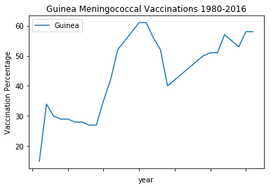

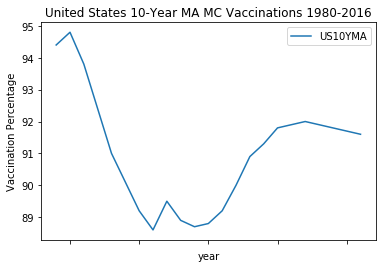

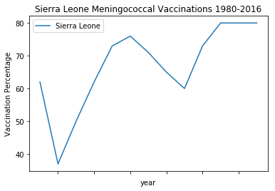

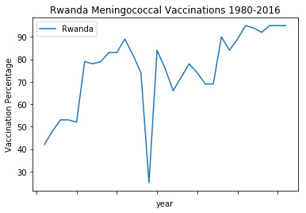

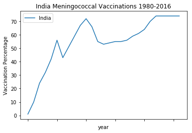

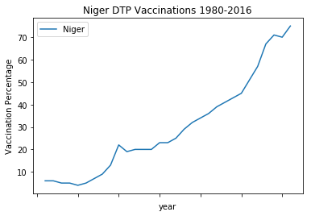

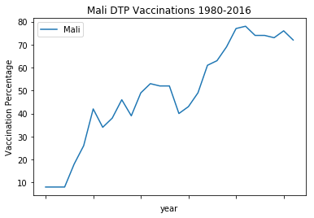

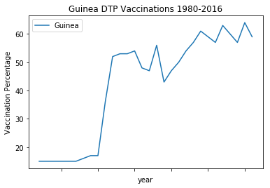

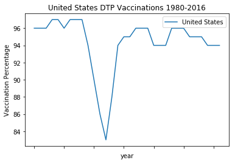

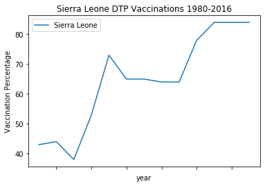

[16 more figures not shown]

```python
mcvdf2['US10YMA'] = mcvdf2['United States'].rolling(window=10).mean()

dicset = {'mcv' : {'Niger':'Niger Meningococcal Vaccinations 1980-2016',
                'Mali': 'Mali Meningococcal Vaccinations 1980-2016',
                'Guinea':'Guinea Meningococcal Vaccinations 1980-2016',
                'US10YMA':'United States 10-Year MA MC Vaccinations 1980-2016',
                'Sierra Leone':'Sierra Leone Meningococcal Vaccinations 1980-2016',
                'Rwanda':'Rwanda Meningococcal Vaccinations 1980-2016',
                'India':'India Meningococcal Vaccinations 1980-2016'},
         'dtp': {'Niger':'Niger DTP Vaccinations 1980-2016',
                'Mali': 'Mali DTP Vaccinations 1980-2016',
                'Guinea':'Guinea DTP Vaccinations 1980-2016',
                'United States':'United States DTP Vaccinations 1980-2016',
                'Sierra Leone':'Sierra Leone DTP Vaccinations 1980-2016',
                'Rwanda':'Rwanda DTP Vaccinations 1980-2016',
                'India':'India DTP Vaccinations 1980-2016'},
         'hepb': {'Niger':'Niger HepB Vaccinations 1980-2016',
                'Mali': 'Mali HepB Vaccinations 1980-2016',
                'Guinea':'Guinea HepB Vaccinations 1980-2016',
                'United States':'United States HepB Vaccinations 1980-2016',
                'Sierra Leone':'Sierra Leone HepB Vaccinations 1980-2016',
                'Rwanda':'Rwanda HepB Vaccinations 1980-2016',
                'India':'India HepB Vaccinations 1980-2016'},
         'im': {'Niger':'Niger Infant Mortality 1980-2018',
                'Mali': 'Mali Infant Mortality 1980-2018',
                'Guinea':'Guinea Infant Mortality 1980-2018',
                'United States':'United States Infant Mortality 1980-2018',
                'Sierra Leone':'Sierra Leone Infant Mortality 1980-2018',
                'Rwanda':'Rwanda Infant Mortality 1980-2018',
                'India':'India Infant Mortality 1980-2018'}}

def plotter(elem, df):
     for k,v in dicset[elem].items():
        df.plot.line(x='year', y=k, title=v)
        plt.pyplot.ylabel('Vaccination Percentage')

names = {'mcv':mcvdf2,
         'dtp':dtpdf2,
         'hepb':hepbdf2,}

for elem,df in names.items():
    plotter(elem, df)



def plotterIM(elem, df):
     for k,v in dicset[elem].items():
        df.plot.line(x='year', y=k, title=v)
        plt.pyplot.ylabel('Infant Mortality Per 1k Births')

imname = {'im':imdf2}

for elem,df in imname.items():
    plotterIM(elem, df)
```

Using data from countries with high rates of infant mortality will give the clearest results. Due to some issues with South Sudan having such high null values for their vaccination rates I decided to drop them. India was also chosen for having an exceptionally low rate of vaccination despite not ranking in the top for infant mortality. The countries chosen to be observed were: Niger, Mali, Guinea, Mozambique, Rwanda, and India.

As a quick preliminary a quick line plotting function was made to just see what some of the trends would look like. A rolling average of US MCV Vaccine Data is present as it was originally thought useful, but then dropped when it became clear that countries with higher infant mortality and low vaccines would give the clearest results. Most of the data lined up with expectations. One interesting blip is in Rwanda's data where you can see the devastating effects of the 1994 genocide.

```python
#Automated slicing as best I could. Function takes in the list of strings corresponding
#to countries, then separates that country's column and the year column, reassigning it to
#a new dataframe. Standard naming became the first two letters of the country combined
#with the abbreviation of the dataframe it came from. Ex: 'Rwanda Infant Mortality' became 'rwim'
country = ['Niger','Mali','Guinea','Mozambique','Rwanda','India']

def slice_df(df, x):
    y = df[['year', x]]
    return y

nimcv,mamcv,gumcv,momcv,rwmcv,inmcv = [slice_df(mcvdf2,x) for x in country]

nidtp,madtp,gudtp,modtp,rwdtp,indtp = [slice_df(dtpdf2,x) for x in country]

nihepb,mahepb,guhepb,mohepb,rwhepb,inhepb = [slice_df(hepbdf2,x) for x in country]

niim,maim,guim,moim,rwim,inim = [slice_df(imdf2,x) for x in country]

nile,male,gule,mole,rwle,inle = [slice_df(ledf2,x) for x in country]
```

```python
niim.rename(columns={'Niger':'Niger Infant Mortality'}, inplace=True)
maim.rename(columns={'Mali':'Mali Infant Mortality'}, inplace=True)
guim.rename(columns={'Guinea':'Guinea Infant Mortality'}, inplace=True)
moim.rename(columns={'Mozambique':'Mozambique Infant Mortality'}, inplace=True)
rwim.rename(columns={'Rwanda':'Rwanda Infant Mortality'}, inplace=True)
inim.rename(columns={'India':'India Infant Mortality'}, inplace=True)

nimcv.rename(columns={'Niger':'Niger MC Vaccinations'}, inplace=True)
mamcv.rename(columns={'Mali':'Mali MC Vaccinations'}, inplace=True)
gumcv.rename(columns={'Guinea':'Guinea MC Vaccinations'}, inplace=True)
momcv.rename(columns={'Mozambique':'Mozambique MC Vaccinations'}, inplace=True)
rwmcv.rename(columns={'Rwanda':'Rwanda MC Vaccinations'}, inplace=True)
inmcv.rename(columns={'India':'India MC Vaccinations'}, inplace=True)

nidtp.rename(columns={'Niger':'Niger DTP Vaccinations'}, inplace=True)
madtp.rename(columns={'Mali':'Mali DTP Vaccinations'}, inplace=True)
gudtp.rename(columns={'Guinea':'Guinea DTP Vaccinations'}, inplace=True)
modtp.rename(columns={'Mozambique':'Mozambique DTP Vaccinations'}, inplace=True)
rwdtp.rename(columns={'Rwanda':'Rwanda DTP Vaccinations'}, inplace=True)
indtp.rename(columns={'India':'India DTP Vaccinations'}, inplace=True)

nihepb.rename(columns={'Niger':'Niger HepB Vaccinations'}, inplace=True)
mahepb.rename(columns={'Mali':'Mali HepB Vaccinations'}, inplace=True)
guhepb.rename(columns={'Guinea':'Guinea HepB Vaccinations'}, inplace=True)
mohepb.rename(columns={'Mozambique':'Mozambique HepB Vaccinations'}, inplace=True)
rwhepb.rename(columns={'Rwanda':'Rwanda HepB Vaccinations'}, inplace=True)
inhepb.rename(columns={'India':'India HepB Vaccinations'}, inplace=True)

nile.rename(columns={'Niger':'Niger Life Expectancy'}, inplace=True)
male.rename(columns={'Mali':'Mali Life Expectancy'}, inplace=True)
gule.rename(columns={'Guinea':'Guinea Life Expectancy'}, inplace=True)
mole.rename(columns={'Mozambique':'Mozambique Life Expectancy'}, inplace=True)
rwle.rename(columns={'Rwanda':'Rwanda Life Expectancy'}, inplace=True)
inle.rename(columns={'India':'India Life Expectancy'}, inplace=True)
```

```python
#Again an attempt to automate an otherwise tedious and lengthy set of merges. The merg function
#takes in a list of tuples, each containing the two dataframes to be merged, it returns
#a left-merged dataframe that merges on 'year'. Afterward list comprehension is used to assign it
#to a new variable.


#First merge, Infant Mortality and MC Vaccinations

merger = [(niim,nimcv),
          (maim,mamcv),
          (guim,gumcv),
          (moim,momcv),
          (rwim,rwmcv),
          (inim,inmcv)]

def merg(k,v):
    y = k.merge(v, on='year')
    return y

niproto,maproto,guproto,moproto,rwproto,inproto = [merg(k[0],k[1]) for k in merger]


#Second merge, first merged df with DTP Vaccinations


mergersecond = [(niproto,nidtp),
          (maproto,madtp),
          (guproto,gudtp),
          (moproto,modtp),
          (rwproto,rwdtp),
          (inproto,indtp)]


nimerg,mamerg,gumerg,momerg,rwmerg,inmerg = [merg(k[0],k[1]) for k in mergersecond]


#Final merge, second merged df with Life Expectancy


mergerthird = [(nimerg,nile),
           (mamerg,male),
           (gumerg,gule),
           (momerg,mole),
           (rwmerg,rwle),
           (inmerg,inle)]


nidf,madf,gudf,modf,rwdf,indf = [merg(k[0],k[1]) for k in mergerthird]
```

```python
#Finally the six separate dfs were merged into one final df in the case case that cross
#comparisons, or more automation would become necessary

finaldf = nidf.merge(madf, on = 'year')
finaldf = finaldf.merge(gudf, on = 'year')
finaldf = finaldf.merge(modf, on = 'year')
finaldf = finaldf.merge(rwdf, on = 'year')
finaldf = finaldf.merge(indf, on = 'year')
```

Some of the heaviest cleaning happened in this area and results in the final seven dataframes that will be used for anaylsis. In the first cell above the cells were prepped for merging by renaming the columns I would be slicing and then merging. This was to prevent confusion with columns of the same name being merged together, and made for clearer plotting.

With five dataframes for each of the six countries a function to merge them in a less cluttered and time consuming way was developed and implemented. It was also at this point that the HepB data was considered too lacking to help, merging with so many null values would have negatively affected either the years available for analysis, or made plotting difficult for little return. The data was still spliced into its own df, but never merged into any of the final seven dataframes.

Once each country's data was succesfully split into dfs a final df of the combined data was created in case it was found necessary for ease of data plotting, both in terms of automation and if analysis across separate countries became relevant.

## Exploratory Data Analysis

### Does a correlation exist between vaccination rates and infant mortality?

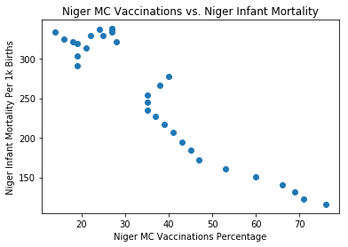

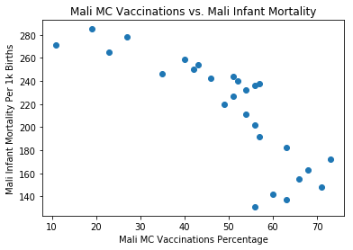

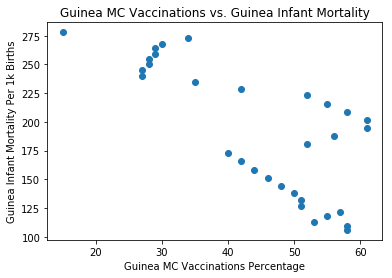

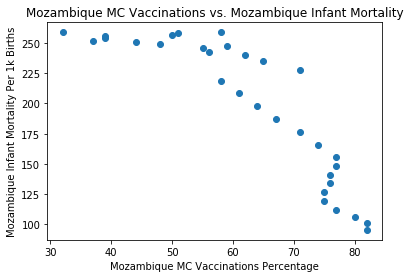

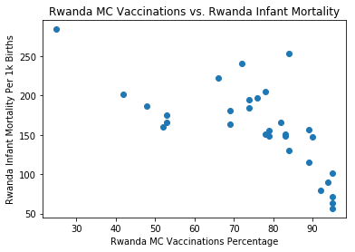

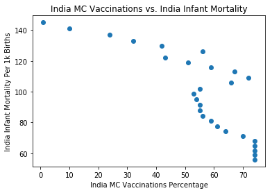

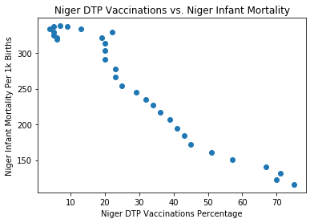

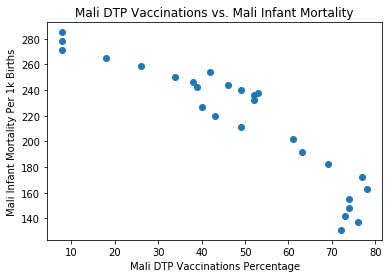

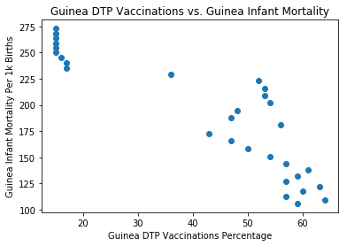

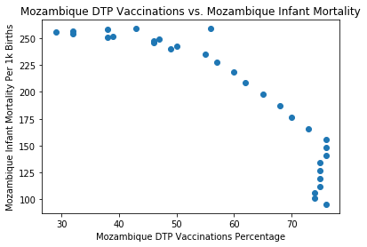

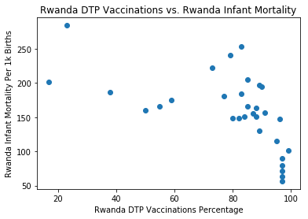

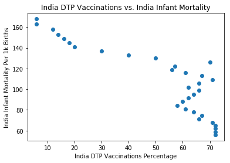

[1 more figures not shown]

```python
# Use this, and more code cells, to explore your data. Don't forget to add
#   Markdown cells to document your observations and findings.
scatdic = {'Niger MC Vaccinations':'Niger Infant Mortality','Mali MC Vaccinations':'Mali Infant Mortality',
           'Guinea MC Vaccinations':'Guinea Infant Mortality','Mozambique MC Vaccinations':'Mozambique Infant Mortality',
           'Rwanda MC Vaccinations':'Rwanda Infant Mortality','India MC Vaccinations':'India Infant Mortality',
           'Niger DTP Vaccinations':'Niger Infant Mortality','Mali DTP Vaccinations':'Mali Infant Mortality',
           'Guinea DTP Vaccinations':'Guinea Infant Mortality','Mozambique DTP Vaccinations':'Mozambique Infant Mortality',
           'Rwanda DTP Vaccinations':'Rwanda Infant Mortality','India DTP Vaccinations':'India Infant Mortality'}


for k,v in scatdic.items():
    plt.pyplot.scatter(finaldf[k], finaldf[v])
    plt.pyplot.xlabel(k + ' Percentage')
    plt.pyplot.ylabel(v + ' Per 1k Births')
    plt.pyplot.title(k + ' vs. ' +v)
    plt.pyplot.show()

for k,v in scatdic.items():
    plt.pyplot.scatter(finaldf[k], finaldf[v])
    plt.pyplot.xlabel('Vaccination Rate Percentage')
    plt.pyplot.ylabel('Infant Mortality Per 1k Live Births')
    plt.pyplot.title('Combined Vaccination Percentage vs. Infant Mortality Per 1k Births')
```

Once the data was assembled a quick scatter plot function was set up to run the data through in an efficient manner. Plots were made observing only the affects of vaccinations on infant mortality, and a final plot was made to look at all the data graphed at once. Looking at the graphs there is a very clear inverse correlation between vaccination rates and infant mortality rates, most notably in Niger's DTP Vaccination plot.

> 1. Guinea's vaccination rates never go much higher than 60% of one year olds where as most of the other countries peak near at least 75%, meaning it may be harder to see the MC Vaccine's effect on infant mortality
> 2. There is a sharp spike in MC Vaccination rates around the mid-ninties. A quick search revealed that in 1992 and 1993 there was a severe meningococcal outbreak in Guinea that didn't taper off until 1994 (https://www.ncbi.nlm.nih.gov/pmc/articles/PMC3691489/,). This outbreak would cause an increase in infant mortality which would in turn lead to an increase in vaccinations as a response, explaining the outlier.

### Does this correlation extend to overall life expectancy?

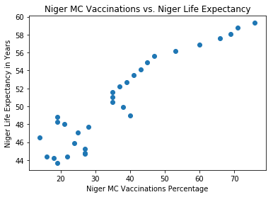

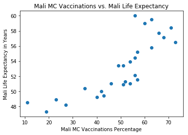

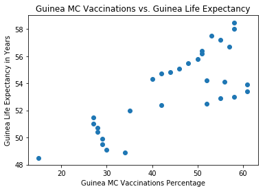

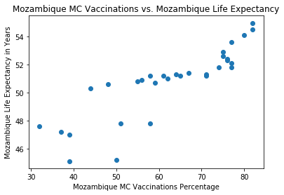

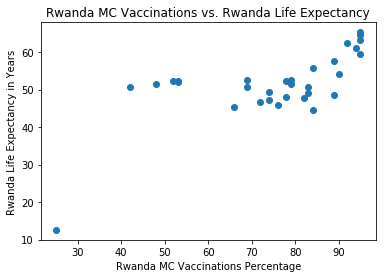

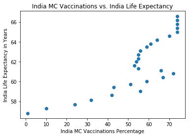

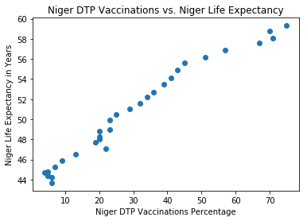

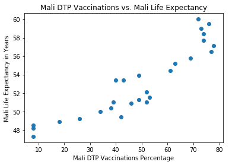

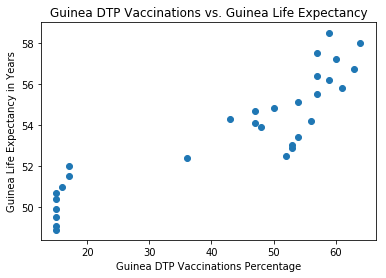

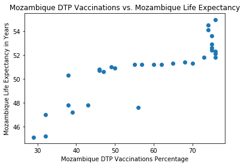

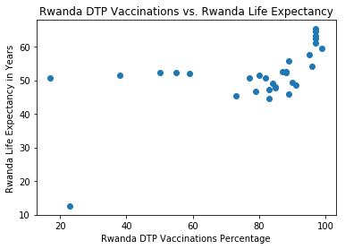

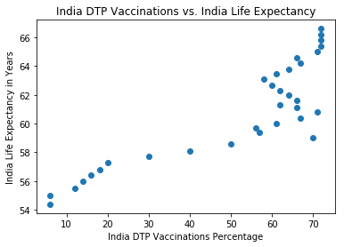

[1 more figures not shown]

```python
# Use this, and more code cells, to explore your data. Don't forget to add
#   Markdown cells to document your observations and findings.
scatdic = {'Niger MC Vaccinations':'Niger Life Expectancy','Mali MC Vaccinations':'Mali Life Expectancy',
           'Guinea MC Vaccinations':'Guinea Life Expectancy','Mozambique MC Vaccinations':'Mozambique Life Expectancy',
           'Rwanda MC Vaccinations':'Rwanda Life Expectancy','India MC Vaccinations':'India Life Expectancy',
           'Niger DTP Vaccinations':'Niger Life Expectancy','Mali DTP Vaccinations':'Mali Life Expectancy',
           'Guinea DTP Vaccinations':'Guinea Life Expectancy','Mozambique DTP Vaccinations':'Mozambique Life Expectancy',
           'Rwanda DTP Vaccinations':'Rwanda Life Expectancy','India DTP Vaccinations':'India Life Expectancy'}


for k,v in scatdic.items():
    plt.pyplot.scatter(finaldf[k], finaldf[v])
    plt.pyplot.xlabel(k + ' Percentage')
    plt.pyplot.ylabel(v + ' in Years')
    plt.pyplot.title(k + ' vs. ' +v)
    plt.pyplot.show()

for k,v in scatdic.items():
    plt.pyplot.scatter(finaldf[k], finaldf[v])
    plt.pyplot.xlabel('Vaccination Rate Percentage')
    plt.pyplot.ylabel('Life Expectancy in Years')
    plt.pyplot.title('Combined Vaccination Percentage vs. Life Expectancy in Years')
```

Here the more long term effects of vaccination on life expectancy can be seen. The positive correlation here is even clearer than the inverse correlation between infant mortality and vaccination rates. Again Guinea and MC Vaccinations prove to be a very minor outlier, however again that is likely due to the meningitis outbreaks in the early to mid-ninties.

Sadly here is another opportunity to see the horrific consequences of the Rwandan Genocide in 1994, where the life expectancy drops to just barely over 10.

## Conclusions

#### Data Limitations:

> Going into the data there were several roadblocks that kept this data from being as comprehensive as would be desired. First and foremost none of the vaccine data is from before 1980, while the infant mortality and life expectancy data stretch back to 1800 which really limits the ammount of information available for comparison. Secondly, of that some of the vaccine data was riddled with null values (HepB), causing it to be dropped altogether from the analysis. Also anomalies such as the Rwandan genocide and the meningitis outbreak in Guinea skewed the data. Thirdly, though the countries chosen for analysis were picked for yielding the clearest results, they still only represent a small sample size of the overall world population, and may not match trends from more affluent nations with different healthcare standards.

> Lastly, while these correlations seem very clear it would be irresponsible to rule out other factors. As healthcare standards and quality of life increase worldwide life expectancy increases and infant mortality decreases. While vaccination rates are likely to increase with these factors there are others at play which were not observed in this analysis. That being said, this evidence is still hard to ignore and definitely warrants further investigation.